# CSC8631 : Data Management and Explore Data Analysis——Online Learning

Minye Shao

2019/11/21

# The presentation structure

- Project objectives
- Business understanding
- Data Understanding
- Data visualization(Analysis of correct answer rate)

# Project objectives

The purpose of this project is to explore and manage data by using R language to sort out and filter the previously disordered data, and finally present the data of cyber security to ordinary people in a visual way,this will make it easier for them to effectively understand the concepts behind the original data

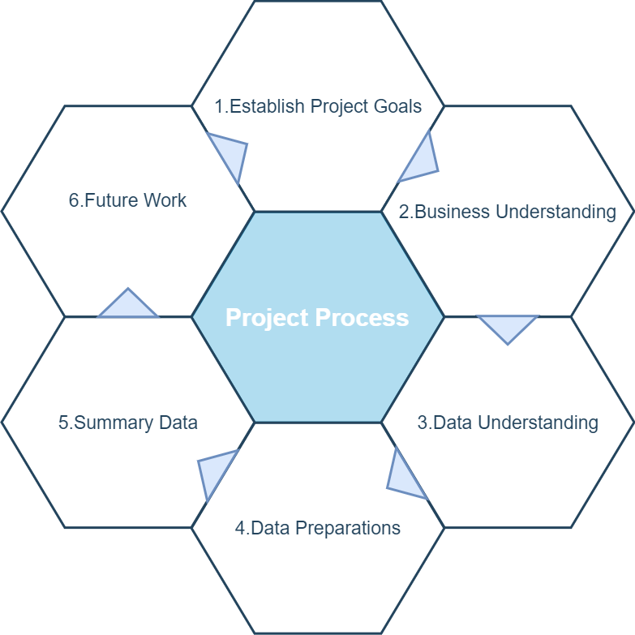

# Business understanding

- With the development of society and science, data analysis and processing are more and more widely used.The focus of this project is to use the data from the online course of Newcastle university in the UK as the prototype, and to draw some effective conclusions by using the CRISP-DM model and EDA (exploratory data analysis).Through these conclusions, we hope we can improve the course arrangement in the future and effectively improve the quality of this course.
- We hope that the course of cyber security will be well known and everyone can effectively acquire the knowledge they want after finishing this course.
- In addition, the study of online courses is more free, with the development of the education industry, more and more people will choose online courses to study, which is a flexible time choice and high-quality education.Therefore, universities can take advantage of this opportunity to increase their income.

# Data Understanding

### A basic overview of the data

- Our data comes from Newcastle university’s online course: cyber security.
- There are two types of data: static data and fluid data.
- “Static data” is data that has traditionally been collected by certain institutions, which can be records in universities.
- “Fluid data” is collected from everyday activities, such as swiping student card and logging into virtual online learning classrooms.
- We have seven terms for the course data, and are ranked from cyber_security 1 to cyber_security 7, each of which means a new cycle for the course. These raw data recorded a lot of necessary and meaningful information but it needs to be filtered and processed before it can be used.

### Defects in the original data

- There are many null values and Unknown values in the original data. I think null values can be properly processed, such as elimination or screening, but I will keep Unknown values, because removing Unknown values is equivalent to reducing the sample size and affecting the authenticity of samples
- Some of the CSV files in the original data don’t give me enough information to process efficiently
- The raw data itself cannot be directly used as the input values presented in the visual diagram. We need to process the data into the way we want it to be before screening it to get the diagram we want

### Data preprocessing

- When I look at the given set of raw data, I finally chose 3 of them as the main object of processing the data, they are: “enrolments”, “question response”, and “step activity”.
- Here are some data preprocessing example:

  > head(Q2.6)  
  > # A tibble: 6 x 12  
  > X learner_id quiz_question Average.time.in~ week_number Time.of.first.a~ Time.of.last.at~ Total.number.of~  
  > 1 1 005d686d-~ 1.8.1 0 1 2018/6/15 14:58 2018/6/15 14:58  
  > 2 2 005d686d-~ 1.8.2 4 1 2018/6/15 14:59 2018/6/15 14:59  
  > 3 3 005d686d-~ 1.8.3 0 1 2018/6/15 15:00 2018/6/15 15:00  
  > 4 4 005d686d-~ 1.8.4 0 1 2018/6/15 15:00 2018/6/15 15:00  
  > 5 5 005d686d-~ 1.8.5 0 1 2018/6/15 15:01 2018/6/15 15:01  
  > 6 6 005d686d-~ 1.8.6 6 1 2018/6/15 15:02 2018/6/15 15:02  
  > # … with 4 more variables: The.total.amount.of.time.it.took.to.get.the.problem.right.unit.s. ,  
  > # The.correct.number , Wrong.number , The.correct.rate.digits.2.
- Taking “question_response.csv” as an example, through integration, we can collect all the answer data under a student id into one piece, which will greatly enhance the usability of the original data

# Data visualization